# Laboratorio 4

# Distribuidora del Sur, S.A.

## Análisis de facturación mensual

La facturación mensual del 2017 pareciera uniforme, sin embargo se registraron caídas en los meses de marzo, junio, y septiembre.

```r
ingreso_mensual <- df %>%
  group_by(ANIO, MES) %>%
  filter(TIPO.DE.ENTREGA!='DEVOLUCION') %>%
  summarise(FACTURACION = sum(Q))
ingreso_mensual %>%
  hchart("column", hcaes(x = MES, y = FACTURACION)) %>%
  hc_title(text = "<b>Facturacion mensual<b>") %>%
  hc_subtitle(text = "<i>Se ve una caida en ingresos en los meses de marzo, junio y septiembre del 2017<i>")
```

[interactive chart not shown]

```r
NA
```

Estos montos facturados provienen de dos ubicaciones, que asumiré que son las bodegas de Distribuidora, S.A. Lo siguiente es analizar si una ubicación factura más que la otra, o no hay diferencia.

```r
ingreso_por_ubicacion <- df %>%
  group_by(ANIO, MES, UBICACION) %>%
  filter(TIPO.DE.ENTREGA!='DEVOLUCION') %>%
  summarise(FACTURACION = sum(Q))
ingreso_por_ubicacion %>%
  hchart('column', hcaes(x = MES, y = FACTURACION, group = UBICACION)) %>%
  hc_colors(c("#0073C2FF", "#EFC000FF")) %>%
  hc_title(text = "<b>Facturacion por ubicacion<b>")
```

[interactive chart not shown]

## Análisis del crédito a clientes

La empresa maneja tres tipos de crédito: a 30, 60 y 90 días. La siguiente gráfica muestra el monto en quetzales facturado mensualmente por tipo de crédito. Vemos que no existe una política clara en cuanto a cómo manejan en crédito con sus clientes, pues hay meses en donde se acredita más a 30 días y otros donde se acredita más a 60 días.

```r
credito <- df %>%
  group_by(ANIO, MES, CREDITO) %>%
  filter(TIPO.DE.ENTREGA!='DEVOLUCION') %>%
  summarise(FACTURACION = sum(Q))
credito %>%
  hchart('column', hcaes(x = MES, y = FACTURACION, group = CREDITO)) %>%
  hc_colors(c('green','blue','orange')) %>%
  hc_title(text = "<b>Facturacion por dias de credito<b>")
```

[interactive chart not shown]

### Ingresos reales a caja

Al no tener una política clara las entradas de efectivo a lo largo del año no serán constantes y pueden sufrir caídas como lo muestra la siguiente gráfica. En ella se muestra la cantidad de dinero en Q. que entra cada mes, con base a lo facturado según su tipo de crédito.

```r
credito$MES <- as.numeric(credito$MES)
credito$MES.INGRESO <- ifelse(test = credito$CREDITO=='30', yes = credito$MES+1,
                              no = ifelse(test = credito$CREDITO=='60', yes = credito$MES+2,
                                          no = credito$MES+3))
proyeccion_caja <- credito %>%
  filter(MES.INGRESO>3 & MES.INGRESO<=12) %>%
  select(ANIO, MES.INGRESO, FACTURACION) %>%
  group_by(ANIO, MES.INGRESO) %>%
  summarise(INGRESO = sum(FACTURACION)) %>%
  mutate(MES.INGRESO = as.factor(MES.INGRESO))
proyeccion_caja %>%
  hchart('column', hcaes(x = MES.INGRESO, y = INGRESO)) %>%
  hc_title(text = "<b>Ingresos percibidos a caja<b>") %>%
  hc_subtitle(text = "<i>Se registra una caida en ingresos en los meses de mayo y septiembre<i>")
```

[interactive chart not shown]

Mi primera recomendación es que se establezca una política de la proporción mensual de facturación para cada tipo de crédito. Es decir, que por ejemplo se facture un 60% con crédito a 30 días, 25% con crédito a 60 días y 15% con crédito a 90 días.

## Análisis de uso de vehículos

Existen actualmente en la empresa tres tipos de unidades para el transporte de mercadería: Paneles, Camiones pequeños y camiones grandes. El mayor número de viajes es con camión grande. Los camiones grandes y pequeños, hasta noviembre del 2017 realizaron 1200 y 600 viajes respectivamente, Sin embargo, los paneles se quedaron un poco abajo de 400, mi recomendación es que se tenga la meta de los 400 y que para esto se adquiera una panel más.

```r
vehiculos <- df %>%
  group_by(UNIDAD) %>%
  summarise(NO.VIAJES = n())

# Bar chart del numero de viajes

vehiculos %>%
  hchart('column', hcaes(x = UNIDAD, y = NO.VIAJES)) %>%
  hc_title(text = "<b>No. de Viajes por tipo de unidad<b>") %>%
  hc_subtitle(text = "<i>Los camiones tipo Panel podrian llegar a 400 viajes<i>")
```

[interactive chart not shown]

```r
NA
```

## Análisis de efectividad de pilotos

Hay 9 pilotos en la empresa y cada uno maneja los tres tipos de unidades. Hay algunos que se desempeñan mejor con cierto tipo de unidad. Por lo que recomiendo que a estos se les asignen más viajes con esas unidades y se esta manera poder maximizar el número de viajes en total.

```r
pilotos <- df %>%
  group_by(PILOTO,UNIDAD) %>%
  summarise(VIAJES = n())
pilotos %>%
  hchart('column', hcaes(x = PILOTO, y = VIAJES, group = UNIDAD)) %>%
  hc_colors(c('green','blue','orange')) %>%
  hc_title(text = "<b>No. de Viajes por piloto y tipo de unidad<b>")
```

[interactive chart not shown]

Adicionalmente considero buena idea proponer la meta de 250 viajes en total para todos los pilotos, y dar alguna bonificación por viaje extra cuando supere la meta antes del tiempo límite.

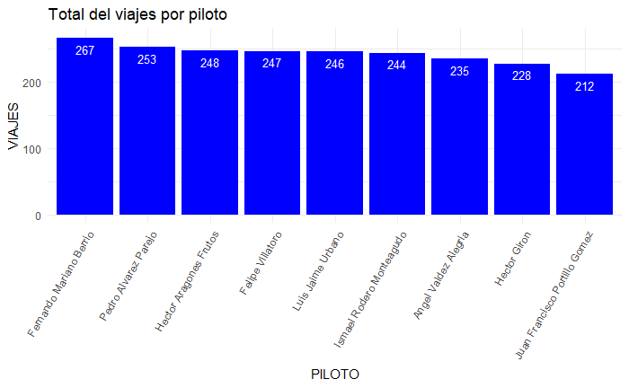

```r
pilotos2 <- pilotos %>%
  group_by(PILOTO) %>%
  summarise(VIAJES = sum(VIAJES))


ggplot(data = pilotos2, mapping = aes(x = reorder(PILOTO,-VIAJES), y = VIAJES)) + geom_bar(stat = 'identity', fill='blue') +
  theme_minimal() +
  theme(axis.text.x = element_text(angle = 60, vjust = 1, hjust=1)) +
  geom_text(aes(label=VIAJES), vjust=1.6, color="white", size=3.5) +
  ggtitle("Total del viajes por piloto") + xlab("PILOTO")
```

## 80/20 de Clientes

La empresa mantiene relación con 13 clientes, esta gráfica muestra el porcentaje de la facturación total a noviembre de 2017 para cada cliente. Vemos que solo a 4 de ellos se les factura casi el 50% del total que factura Distribuidora, S.A.

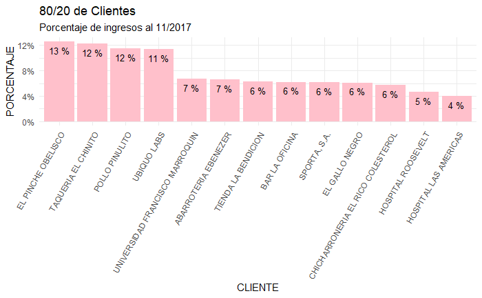

```r
clientes <- df %>%
  group_by(CLIENTE) %>%
  filter(TIPO.DE.ENTREGA!='DEVOLUCION') %>%
  summarise(FACTURADO = sum(Q))
clientes$PORCENTAJE <- 100*clientes$FACTURADO/sum(clientes$FACTURADO)

ggplot(data = clientes, mapping = aes(x = reorder(CLIENTE,-PORCENTAJE), y = PORCENTAJE)) + geom_bar(stat = 'identity',fill='pink')+
  theme_minimal()+
  theme(axis.text.x = element_text(angle = 60, vjust = 1, hjust=1)) +
  geom_text(aes(label=paste(round(PORCENTAJE,0),"%")), vjust=1.6, color="black", size=3.5)+
  scale_y_continuous(labels = function(x) paste0(x, "%"))+
  ggtitle("80/20 de Clientes", subtitle = "Porcentaje de ingresos al 11/2017") + xlab("CLIENTE")
```

Mi recomendación es que se les ofrezcan más beneficios a estos 4 clientes, como descuentos o que sean solo estos clientes los que tengan la opción de 90 días de crédito.